# part4_selectionprobability

## Introdution to selection probability

Regularization procedure, 특히 lasso,는 변수선택 측면에서 매우 좋은 성능을 보여주었다. 그러나 최적의 tuning parameter를 선택하는 문제에 있어서 매우 신중해야한다. tuning parameter에 따라 coefficients 값에 차이가 있는 불안정성을 보여준다. tuning parameter에 관계없이 변수 선택에 대한 지표를 나타내는 selection probability를 제안했다.

selection probability는 다음과 같은 알고리즘을 통해 계산된다. 저희는 현재 elastic-net 모형에서 lambda와 alpha 두개의 tuning parameters를 갖고 있기 때문에, 모든 alpha와 lambda 그리드에 대하여 N/2 사이즈의 subsample을 선택하여 elastic-net 모형의 coefficients를 구하는 과정을 총 K번 반복합니다. 이 때, K는 많을수록 좋으며 최소 100이상의 값을 가지는 것을 추천드립니다. K번의 반복을 통해 각가의 tuning parameter grid에서 각 변수가 선택된 횟수의 최댓값을 K로 나누어 selection probability를 계산합니다. 그리고 tuning parameter grid 중에서 sp의 최대값을 최종 sp로 정의합니다.

간단하게 말해서 selection probability는 총 K번 반복 중에서 몇번 선택되는지 비율의 tuning parameter에 대한 최댓값을 뜻합니다.

```r
library(glmnet)
load("[Data]PNU-winter-workshop-2019.RData")

attach(workshop.data)
```

## Introdution to selection probability

```r
library(glmnet)
alpha.grid <- seq(0.1, 0.9, 0.1)
lambda.mat <- array( NA, dim = c(length(alpha.grid), 10, 10),
                 dimnames=list(paste0("alpha=", alpha.grid),
                               paste0("lambda", 1:10),
                               paste0("REP=", 1:10)) )

for( REP in 1:10 ){
  for( i in 1:length(alpha.grid) ){
    set.seed( 1000*REP + i )
    sp.subset <- sample( nrow(x), floor(nrow(x)/2) )
    lambda.mat[i,,REP] <- glmnet(x=x[sp.subset,], y=y[sp.subset], family="gaussian",
                             alpha=alpha.grid[i], nlambda=10)$lambda
  }
}
# save(lambda.mat, file="[object]lambda.mat.RData")
```

```r
load("[object]lambda.mat.RData")
lambda.grid <- seq( summary(lambda.mat)[2], summary(lambda.mat)[4], length.out = 100 )
range(lambda.grid)
```

```
## [1]  69.30751 831.11629
```

```r
sp.array <- array(0, dim=c(ncol(x), length(alpha.grid), length(lambda.grid)) )
K <- 50 ## recommended to be 100 or more
for( k in 1:K ){
  if( k %% 10 == 0 ) cat("A current iteration is ", k, "\n")
  set.seed(123*k)
  sp.subset <- sample( nrow(x), floor(nrow(x)/2) )

  for( i in 1:length(alpha.grid) ){
    for( j in 1:length(lambda.grid) ){
      sp.fit <- glmnet(x=x[sp.subset,], y=y[sp.subset], family="gaussian",
                       alpha=alpha.grid[i], lambda=lambda.grid[j])
      sp.array[,i,j] <- sp.array[,i,j] + as.numeric(sp.fit$beta!=0)/K
    }
  }
}
# save(sp.array, file="[object]sp.array.RData")
```

```r
load("[object]sp.array.RData")

sp <- apply( sp.array, 1, max )

head( data.frame(sp = sort( sp, decreasing=TRUE ), variable = order( sp, decreasing=TRUE ) ) )
```

```
##     sp variable
## 1 0.86    11561
## 2 0.78     9015
## 3 0.70     4287
## 4 0.68     2758
## 5 0.66     8903
## 6 0.66    10095
```

```r
# library(glmnet)
# alpha.grid <- seq(0.1, 0.9, 0.1)
#
# lambda.mat <- array( NA, dim = c(length(alpha.grid), 10, 10),
#                  dimnames=list(paste0("alpha=", alpha.grid), paste0("lambda", 1:10), paste0("REP=", 1:10)) )
# for( REP in 1:10 ){
#   for( i in 1:length(alpha.grid) ){
#     set.seed( 1000*REP + i )
#     sp.subset <- sample( nrow(x), floor(nrow(x)/2) )
#     lambda.mat[i,,REP] <- glmnet(x=x[sp.subset,], y=y[sp.subset], family="gaussian", alpha=alpha.grid[i], nlambda=10)$lambda
#   }
# }
#
# lambda.grid <- seq( summary(lambda.mat)[2], summary(lambda.mat)[4], length.out = 100 )
# lambda.grid
#
# sp.array <- array(0, dim=c(ncol(x), length(alpha.grid), length(lambda.grid)) )
# K <- 50 ## recommended to be 100 or more
# for( k in 1:K ){
#   set.seed(123*k)
#   sp.subset <- sample( nrow(x), floor(nrow(x)/2) )
#
#   for( i in 1:length(alpha.grid) ){
#     for( j in 1:length(lambda.grid) ){
#       sp.fit <- glmnet(x=x[sp.subset,], y=y[sp.subset], family="gaussian", alpha=alpha.grid[i], lambda=lambda.grid[j])
#       sp.array[,i,j] <- sp.array[,i,j] + as.numeric(sp.fit$beta!=0)/K
#     }
#   }
# }
#
# sp <- apply( sp.array, 1, max )
```

```r
sp.threshold <- function(sp, FP=5){
  if(max(sp)>1 | min(sp)<0) stop("'Sel.prob' should be in [0,1].")
  if(length( dim(sp) ) < 3) stop("'sp' should be a 3-dimensional array.")
  qhat <- sum(sp)/(dim(sp)[2]*dim(sp)[3])
  p <- dim(sp)[1]
  threshold <- qhat^2/(2*FP*p) + 0.5

  if(threshold>1) threshold <- 1
  return( threshold )
}

theoretical.threshold5 <- sp.threshold(sp.array, FP=5)
theoretical.threshold10 <- sp.threshold(sp.array, FP=10)

c(theoretical.threshold5, theoretical.threshold10)
```

```
## [1] 0.7129721 0.6064860
```

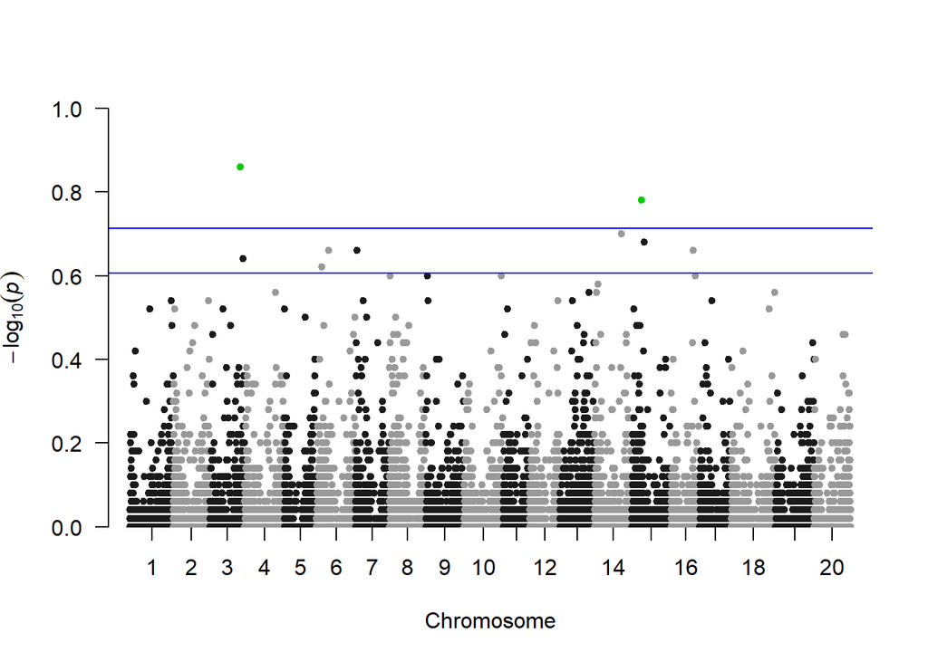

```r
df.sp <- data.frame( ref, p=sp)
colnames(df.sp) <- c("SNP", "CHR", "BP", "P")

var.theoretical.threshold5 <- which( sp > theoretical.threshold5 )

qqman::manhattan(df.sp,
                 chr="CHR", bp="BP", p="P", snp="SNP", logp=FALSE,
                 suggestiveline=c(theoretical.threshold5, theoretical.threshold10),
                 highlight=df.sp[var.theoretical.threshold5, "SNP"],
                 ylim=c(0,1))
```

```r
## Stability selection
stable.lambda <- glmnet(x=x, y=y, family="gaussian", alpha=0.1, nlambda=10)$lambda

stable.sp.out <- array(0, dim=c(ncol(x), length(stable.lambda)) )
K=50
for( k in 1:K ){
  if(k%%10==0) cat("A current iteration is ", k, "\n")
  set.seed(123*k)
  sp.subset <- sample( nrow(x), floor(nrow(x)/2) )
  for( j in 1:length(stable.lambda) ){
    sp.fit <- glmnet(x=x[sp.subset,], y=y[sp.subset], family="gaussian",
                     alpha=0.1, lambda=stable.lambda[j])
    stable.sp.out[,j] <- stable.sp.out[,j] + as.numeric(sp.fit$beta!=0)/K
  }
}
# save(stable.lambda, file="[object]stable.lambda.RData")
# save(stable.sp.out, file="[object]stable.sp.out.RData")
```

```r
load("[object]stable.lambda.RData")
load("[object]stable.sp.out.RData")
var.threshold10 <- which( sp > theoretical.threshold10 )
str(var.threshold10)
```

```
##  int [1:9] 2758 4287 8903 9015 10095 10361 11313 11561 11985
```

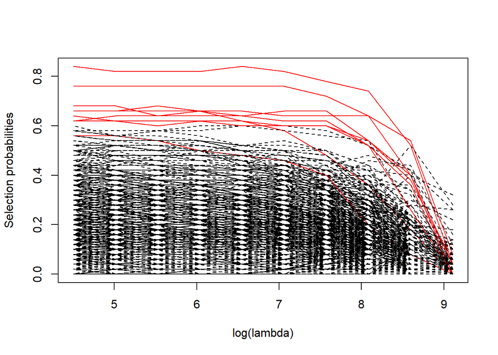

```r
matplot( log(stable.lambda), t(stable.sp.out), type="l",
         lty=ifelse(1:ncol(x) %in% var.threshold10, 1, 2),
         col=ifelse(1:ncol(x) %in% var.threshold10, 2, 1),
         xlab="log(lambda)", ylab="Selection probabilities" )
```

```r
# save.image( file="part4.RData" )
```